# Lake water evaporation model and mass balance calculations for Lake Turkana, Kenya

2022-01-04

# Water isotope measurements

## Data visualization

### Define plot styles

Colorblind-friendly palette from @tol2018.

### Load and process data (this study)

*To do:* Talk about the “Evaporated Surface” data points — all but one are from TBI-Ileret and appear on a line in plot 1; the last is from a pond in Topernawi laga. We should try to find out more about the Ileret conditions and what they capture; the line looks roughly parallel to the LEL. What is the relevance of the Topernawi data point? Is it worth comparing one point each from Topernawi laga and lake shore?

```r
waters.rawdata <- read_csv(here("data/2016-2021_waters.csv"))

# Simplify WaterType categories
waters <- waters.rawdata |>
  mutate(WaterType = str_replace_all(WaterType,
                                     c("River Delta" = "River",
                                       "Deep Ground" = "Ground",
                                       "Shallow Ground" = "Ground",
                                       "Spring" = "Ground",
                                       "Evaporated Surface" = "Surface")))
```

### New measurements

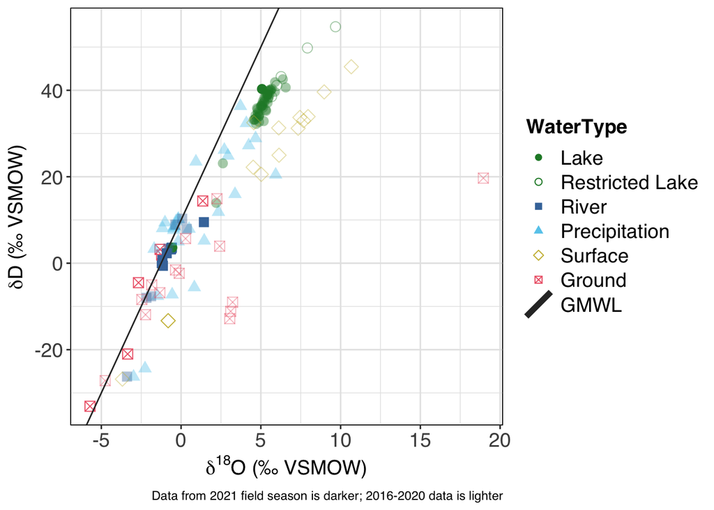

### Load and process published data (@levin2009)

```r
waters.Levin.rawdata <- read_excel(here("data/Levin_et_al_2009_raw_data.xls"))

# Make WaterType categories consistent with this study
waters.Levin <- waters.Levin.rawdata |>
  mutate(WaterType = str_replace_all(Type,
                                     c("spring" = "Ground",
                                       "bore hole" = "Ground",
                                       "river" = "River",
                                       "water hole" = "Ground",
                                       "tap" = "Ground",
                                       "stream" = "Surface",
                                       "well" = "Ground",
                                       "rain" = "Precipitation")))
```

### Published measurements

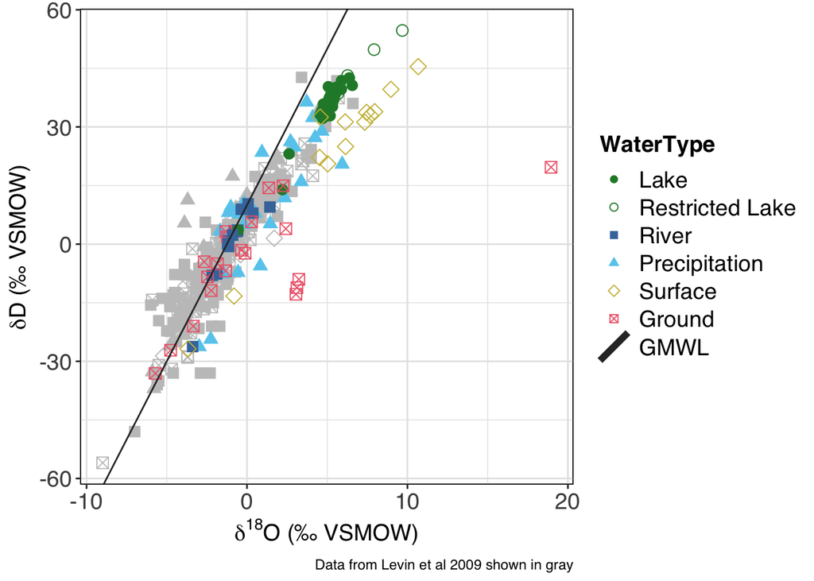

# Local evaporation line model

## Define model function

The function produces a plot-able data frame of δ<sup>18</sup>O and δD values representing isotope composition of evaporate water given isotope values of input water and atmospheric conditions. Formulas and relationships are defined in @gibson2016 and @horita1994.

```r
model.LEL <- function(env.input){

  # Celsius to Kelvin conversion
  TK <- env.input["TC"] + 273.15

  # liquid-vapor fractionation factors (Horita & Wesolowski 1994)
  aD <- exp( ((1158.8 * TK^3)/1e12) - ((1620.1 * TK^2)/1e9) + ((794.84 * TK)/1e6) - (161.04/1e3)  + (2.992e6/TK^3) )
  a18O <- exp( (-7.685e-3) + (6.7123 / TK) - (1.6664e3 / TK^2) + (0.35041e6 / TK^3) )

  # equilibrium isotopic separation (ibid.)
  eD <- (aD - 1) * 1000
  e18O <- (a18O - 1) * 1000

  # diffusion controlled fractionation (ibid.)
  ekD <- 12.5 * (1 - env.input["rh"])
  ek18O <- 14.2 * (1 - env.input["rh"])

  # atmospheric isotope ratios (Gibson et al 2016 eqn 18)
  dDA <- (env.input["dDp"] - (env.input["k"] * eD)) /
    (1 + (1e-3 * env.input["k"] * eD))
  d18OA <- (env.input["d18Op"] - (env.input["k"] * e18O)) /
    (1 + (1e-3 * env.input["k"] * e18O))

  # limiting isotope ratios (Gibson et al 2016 eqn 7)
  dstarD <- ((env.input["rh"] * dDA) + ekD + (eD / aD)) /
    (env.input["rh"] - (1e-3 * (ekD + (eD / aD))))
  dstar18O <- ((env.input["rh"] * d18OA) + ek18O + (e18O / a18O)) /
    (env.input["rh"] - (1e-3 * (ek18O + (e18O / a18O))))

  # temporal enrichment slope (Gibson et al 2016 eqn 6)
  mD <- (env.input["rh"] - (1e-3 * (ekD + (eD / aD)))) /
    ((1 - env.input["rh"]) + (1e-3 * ekD))
  m18O <- (env.input["rh"] - (1e-3 * (ek18O + (e18O / a18O)))) /
    ((1 - env.input["rh"]) + (1e-3 * ek18O))

  # create values for evaporation to inflow ratio (x = E / I) from 0 (no evaporation, lake growing) to 1 (fully evaporated lake)
  # adjust "by" param up or down to have fewer or more points on the model line
  x <- seq(from = 0, to = 1, by = 0.07)

  # lake water isotopes for values of x (Gibson et al 2016 eqn 10) and vapor isotopes (eqn 3)
  dDL <- (env.input["dDi"]  + (mD * x * dstarD)) / (1 + mD * x)
  d18OL <- (env.input["d18Oi"] + (m18O * x * dstar18O)) / (1 + m18O * x)
  dDv <- (((dDL - eD) / aD) - (env.input["rh"] * dDA) - ekD) / (1 - env.input["rh"] + (1e-3 * ekD))
  d18Ov <- (((d18OL - e18O) / a18O) - (env.input["rh"] * d18OA) - ek18O) / (1 - env.input["rh"] + (1e-3 * ek18O))

  # combine modeled lake and vapor delta values in data frame for plotting
  dL <- as.data.frame(cbind("d18O" = d18OL, "dD" = dDL))
  dv <- as.data.frame(cbind("d18O" = d18Ov, "dD" = dDv))
  model.line <- as.data.frame(rbind(dL, dv))

  return(model.line)
}
```

## Model inputs

Build model evaporation lines using environmental conditions. The resulting evaporation line represents these inputs given to the function above.

*To do*: Create a table of input values and generate model results across multiple scenarios

```r
env.conditions <- c(

  # average air temperature (C); evaporation model is most accurate given an air-water interface temperature
  "TC" = 28,

  # average humidity (%rh); evaporation model is most accurate given a value normalized to water surface temperature
  "rh" = 0.25,

  # d18O & dD (permil VSMOW) for lake water input
  "d18Oi" = -0.4,
  "dDi"   = 9,

  # d18O & dD (permil VSMOW) for precipitation
  "d18Op" = 0.9,
  "dDp"   = 10,

  # degree to which there is isotopic equilibrium between precipitation and atmospheric water vapor
  "k" = 0.1
)

result.LEL <- model.LEL(env.conditions)
```

### Model with meteoric waters

Local evaporation model for environmental conditions: TC = 28, rh = 0.25, d18Oi = -0.4, dDi = 9, d18Op = 0.9, dDp = 10, k = 0.1

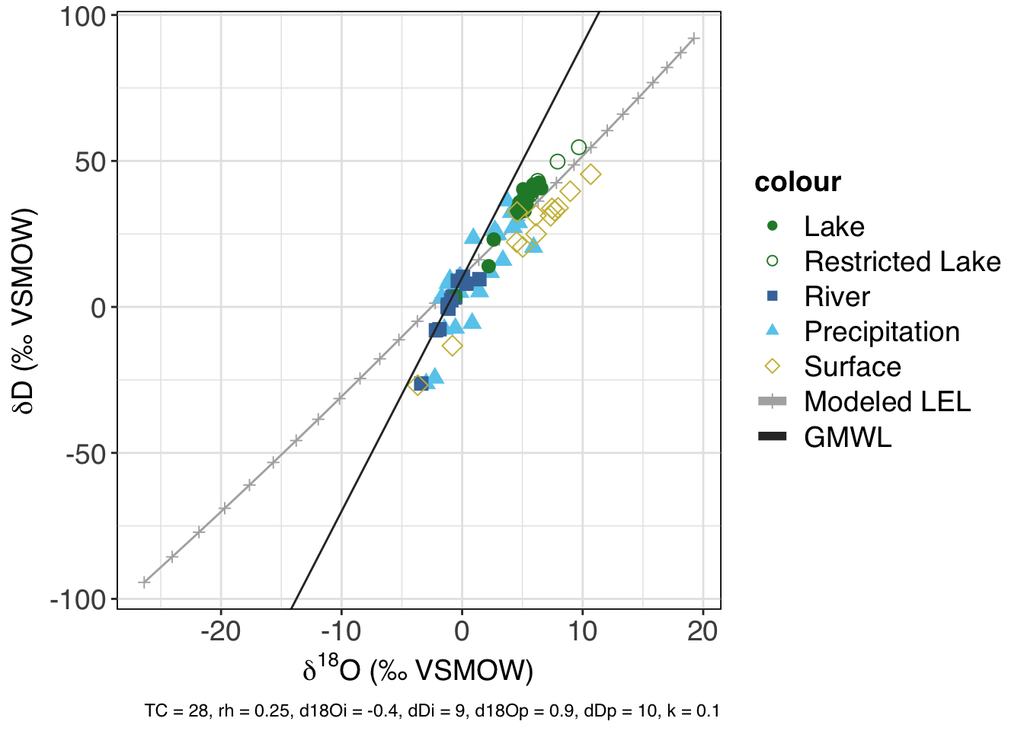

```r
#Filter meteoric waters (all types except ground)
waters.meteoric <- waters |>
  filter(WaterType != "Ground")

plot.LEL <- ggplot(data = result.LEL, aes(x = d18O, y = dD, color = "Modeled LEL")) +

  # plot elements
  geom_point(shape = shape.model) + geom_line() +
  geom_point(data = waters.meteoric,
             aes(x = d18O, y = dD, color = WaterType, shape = WaterType), size = size.st, show.legend = FALSE) +
  geom_abline(data = NULL, aes(slope = 8, intercept = 10, color = "GMWL"), show.legend = FALSE) +

  # legend
  scale_shape_manual(
    breaks = c("Lake", "Restricted Lake", "River", "Precipitation", "Surface", "Modeled LEL", "GMWL"),
    # set plot element shapes
    values = c(
      "Lake" = shape.lake,
      "Restricted Lake" = shape.surface.lake,
      "River" = shape.river,
      "Precipitation" = shape.precip,
      "Surface" = shape.surface,
      "Modeled LEL" = shape.model,
      "GMWL" = 1)) +

  scale_color_manual(
    breaks = c("Lake", "Restricted Lake", "River", "Precipitation", "Surface", "Modeled LEL", "GMWL"),
    # set plot element colors
    values = c(
      "Lake" = color.lake,
      "Restricted Lake" = color.lake,
      "River" = color.river,
      "Precipitation" = color.precip,
      "Surface" = color.surface,
      "Modeled LEL" = color.model,
      "GMWL" = color.GMWL)) +

  guides(color = guide_legend(override.aes=list(
    linetype = c(rep("blank", 5), rep("solid", 2)),
    shape = c(shape.lake, shape.surface.lake, shape.river, shape.precip, shape.surface, shape.model, NA),
    size = 2))) +

  labs(x = axis.x.label,
       y = axis.y.label,
       caption = paste(names(env.conditions), "=", env.conditions, collapse = ", "))

plot(plot.LEL)
```

*To do:* Generate a 4 or 6 panel figure with four sets of input values. Use `apply()` for this?

## Test models

*To do:* Get statistical comparison (ANOVA? T-test?) between each model LEL and the lake waters

### De-trend lake data

*To do:* Subtract LEL model from lake data to check for fit

Like this?

- Get linear equation for LEL
- Apply linear function to lake δ<sup>18</sup>O values to produce data frame of real δ<sup>18</sup>O vs modeled δD
- Use `detrend()` to remove linear trend from new data frame

## Mass balance

Estimate lake volumes from [USDA Foreign Agriculture Service](https://ipad.fas.usda.gov/cropexplorer/global_reservoir/gr_regional_chart.aspx?regionid=eafrica&reservoir_name=Turkana&lakeid=000093) and estimate percent increases in inputs needed.